# VS Code tips and tricks

Optional self-study content for week 10

Author

Affiliations

Jelmer Poelstra

[CFAES Bioinformatics Core, Ohio State University](https://go.osu.edu/bioinformatics-core)

[Dept. of Plant Pathology, Ohio State University](https://plantpath.osu.edu)

Published on

October 10, 2026

Page last modified

October 23, 2026

**WarningThis page is still under construction.**

## 1 Introduction

This page collects tips and tricks that will make you more efficient in VS Code. None of this is required for the course, but the time you invest in learning your editor will pay off quickly, since you’ll spend many hours in it.

Nearly everything here applies both to VS Code at OSC, which runs in your browser, and to a VS Code installation on your own computer.

To try things out as you read, start a VS Code session at https://ondemand.osc.edu (or open your local VS Code installation) and open a file or two, such as one of the scripts you wrote in week 7.

**WarningWhen a keyboard shortcut doesn’t work**

Because VS Code at OSC runs inside your browser, a few keyboard shortcuts are “captured” by the browser instead of by VS Code. For example, `Ctrl/⌘`+`W` may close your *browser tab* rather than the file you have open in the editor. Whenever a shortcut doesn’t do what you expect, you can find the same functionality through the menus or the Command Palette (see below).

## 2 Finding functionality

### 2.1 The Command Palette

The Command Palette is a search box to find and run any VS Code command, including everything that is in the menus. To open it, click > `Command Palette`, or press `F1` or `Ctrl/⌘`+`Shift`+`P`. Then, start typing to search for a command: for example, type “word wrap” to find the command that toggles line wrapping.

The Command Palette also shows the keyboard shortcut for each option, if there is one, so it is a good way to discover shortcuts for things you do often.

### 2.2 Keyboard shortcuts overview

For a single-page PDF overview of keyboard shortcuts for your operating system: > `Help` > `Keyboard Shortcuts Reference`. (Or for direct links to these PDFs on the web: [Windows](https://code.visualstudio.com/shortcuts/keyboard-shortcuts-windows.pdf) / [Mac](https://code.visualstudio.com/shortcuts/keyboard-shortcuts-macos.pdf) / [Linux](https://code.visualstudio.com/shortcuts/keyboard-shortcuts-linux.pdf).)

To see, change, or add keyboard shortcuts, click > `Keyboard Shortcuts`, like you did in week 7 to add the `Ctrl`+`Enter` shortcut to send code to the terminal.

## 3 Working in the editor

### 3.1 Line actions

- **Whole-line actions without selecting**  
  When nothing is selected, some actions apply to the *entire line that your cursor is on*. So you don’t need to select a line first to:
  - **Cut or copy it**, with the standard shortcuts `Ctrl/⌘`+`X` / `C`.
  - **Send it to the terminal**, with the `Ctrl`+`Enter` shortcut you set up in week 7.
- **Move a line up or down**: `Alt/Option`+`⬆`/`⬇`
- **Delete a line**: `Ctrl/⌘`+`Shift`+`K`
- **Comment or uncomment a line**: `Ctrl/⌘`+`/`  
  This inserts or removes the comment character for the current language, e.g. `#` in a shell script. This is handy to temporarily deactivate (“comment out”) code.

All of the above also work for **multiple selected lines at once**.

### 3.2 Go to a specific line

Error messages often mention a line number, as in:

```
scripts/fastqc.sh: line 8: $1: unbound variable
```

To jump to a line, press `Ctrl`+`G` (on a Mac too) and type the line number. Alternatively, click on the `Ln <number>, Col <number>` indicator in the Status Bar at the bottom of the window.

### 3.3 Find and replace

- **Find** in the current file: `Ctrl/⌘`+`F`.
- **Find and replace** in the current file: `Ctrl`+`H` (Windows/Linux) or `Option`+`⌘`+`F` (Mac).
- **Search across all files** in the folder you opened in VS Code: click the magnifying glass icon in the Activity Bar, or press `Ctrl/⌘`+`Shift`+`F`. You can also replace across files from there.

The search box has buttons to make your search case-sensitive (`Aa`), match whole words only (`ab`), or use a regular expression (`.*`).

### 3.4 Multiple cursors

VS Code lets you type in multiple places at once, which is great for making the same edit on several lines:

- **Add a cursor** where you click: hold `Alt/Option` while clicking.
- **Select the next occurrence** of the currently selected text: `Ctrl/⌘`+`D` (press repeatedly to add more occurrences).
- **Column (“box”) selection**: hold `Shift`+`Alt/Option` while dragging your mouse.

Press `Esc` to go back to a single cursor.

## 4 Navigating files and panes

### 4.1 Quick Open

To open a file without clicking through the Explorer, press `Ctrl/⌘`+`P` and start typing (part of) its name.

### 4.2 Opening files from the terminal

If you hold `Ctrl` (Windows/Linux) or `⌘` (Mac) while hovering over a file path in the terminal, the path becomes underlined, and you can click on it to open the file in the editor. This works for paths you typed and for paths that a command printed, such as `scripts/fastqc.sh` in the error message shown above. If the path is followed by a line number, as in `scripts/fastqc.sh:8`, VS Code will even jump straight to that line.

### 4.3 The Explorer

- **Copying a file’s path**  
  Right-click on a file in the Explorer and select `Copy Path` (absolute path) or `Copy Relative Path` (relative to the folder you opened in VS Code). This is handy for pasting file paths into the terminal or into a script.
- **Moving files**  
  You can drag and drop files and folders in the Explorer to move them.
- **Downloading and uploading files**  
  To download a file to your computer, right-click on it in the Explorer and select `Download...`. To upload files, drag them from your computer into a folder in the Explorer. For large or many files, it’s better to use the OnDemand file browser or one of the other methods you’ll learn about in week 11.

### 4.4 Arranging your screen

- **Toggling (hiding/showing) the side bars**  
  If you want to save some screen space while coding along in class, you may want to occasionally hide the side bars:
  - In > `View` > `Appearance`, you can toggle both the `Activity Bar` and the `Primary Side Bar`.
  - For the primary/wide side bar, you can also drag it away, or use the keyboard shortcut `Ctrl/⌘`+`B`.
- **Splitting the editor**  
  To see two files side by side (e.g., a script and your `README.md`), drag an editor tab to the right side of the editor pane, or right-click on a tab and select `Split Right`.
- **Switching between the terminal and the editor**
  - Open a terminal, or move from the editor to the terminal: `Ctrl`+`` ` `` (backtick). Pressing this again while you’re in the terminal hides the panel.
  - Move from the terminal to the editor: `Ctrl/⌘`+`1`. At OSC, your browser may capture this shortcut to switch to your first browser tab — if so, simply click in the editor.

### 4.5 Multiple terminals

You can have multiple terminals open at once — for example, to run a long command in one while you keep working in another. In the terminal panel:

- Click the `+` icon to open a new terminal.
- Switch between terminals in the list on the right side of the panel.
- Click the trash can icon to close (“kill”) a terminal.

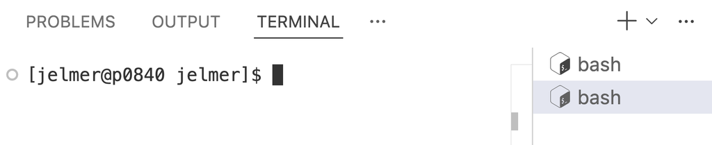

After clicking the `+` icon, you’ll have two terminals:  
see the repeated “bash” in the list on the right side of the panel,  
and you can click on either to switch between them.

You can also split the terminal panel, so you can see two terminals at once, side by side:

[figure not shown]

After clicking the split icon (to the left of the trash can icon), you’ll have two terminals side by side.

Keep in mind that each terminal is a separate shell session: variables you assign and modules you load in one terminal are not available in the other.

## 5 Settings

You can open the Settings via > `Settings`, and then search for the setting you want to change.

**NoteUser settings vs. workspace settings *(Click to expand)**

The Settings editor has two tabs at the top: `User` and `Workspace`.

- **User** settings apply everywhere you use VS Code.
- **Workspace** settings only apply to the folder you currently have open, and are saved in a file `.vscode/settings.json` inside that folder.

Change your User settings unless you have a specific reason to do otherwise.

Some settings you may want to change:

- **Auto Save**  
  In VS Code at OSC, Auto Save is on by default (with the “afterDelay” option: files are saved right after you stop typing), but in a local VS Code installation, it is off by default. To change this:
  - Click > `File` > `Auto Save` to quickly toggle it on or off (it shows a checkmark when it’s on).
  - Search for “Auto Save” in the Settings to pick from several options, such as only saving when you switch to another file or window (“onFocusChange”).
- **Word wrap**  
  By default, long lines run off the right side of the editor. To wrap them instead, click > `View` > `Word Wrap` (or press `Alt/Option`+`Z`). To make this permanent, search for “Word Wrap” in the Settings.
- **Minimap**  
  The “minimap” is the zoomed-out view of your file on the right side of the editor. If you find it distracting, you can hide it via > `View` > `Appearance` > `Minimap`.
- **Font size**  
  To quickly make everything bigger or smaller, press `Ctrl/⌘`+`+` / `-` (at OSC, this zooms the browser page, which has the same effect). To set the font size more precisely, search for “Font Size” in the Settings to change the font size of the editor (“Editor: Font Size”) and, separately, of the terminal (“Terminal › Integrated: Font Size”).
- **A vertical line to mark line length**  
  To keep your lines of code and Markdown text from getting too long, you can show one or more vertical lines (“rulers”) at a specific width: search for “Rulers” in the Settings, click `Edit in settings.json`, and add e.g. `80` between the square brackets: `"editor.rulers": [80]`.
- **Tidying up whitespace**  
  Search for and turn on “Trim Trailing Whitespace” (removes spaces at the ends of lines when you save a file) and “Insert Final Newline” (makes sure a file ends with a newline, which some command-line tools expect).

## 6 Extensions

During the course, we’ve installed several VS Code extensions, which are small programs that add functionality to VS Code. To recap, you can install an extension by clicking the Extensions icon in the Activity Bar (see screenshot on the right), then search for the extension, and click `Install`.

### 6.1 Extensions used in the course

- **HTML Preview** (by *Thomas Haakon Townsend*) — view HTML files, like FastQC output, inside VS Code *(week 6)*.
- **ShellCheck** (by *timonwong*) — check your shell scripts for errors and bad practices *(week 7)*. At OSC, this needs a work-around to function — see the first shell scripting lecture.
- **Quarto** (by *Quarto*) — edit Markdown and Quarto files in a visual editor, and more *(week 7)*.
- **PDF Viewer** (by *Mathematic Inc*) — view PDF files inside VS Code *(week 7)*.
- **Claude Code** (by *Anthropic*) — a code-writing AI assistant *(week 8)*.

[figure not shown]

Activity Bar, with the Extensions icon (bottom) highlighted.

### 6.2 Other useful extensions

- **Rainbow CSV** (by *mechatroner*) — makes CSV/TSV files easier to view in the editor pane, with column-based colors.
- **Code Spell Checker** (by *Street Side Software*) — flags spelling mistakes in your Markdown files and code comments.
- **markdownlint** (by *David Anson*) — checks your Markdown files for formatting issues and inconsistencies.
- **Markdown All in One** (by *Yu Zhang*) — adds keyboard shortcuts for Markdown formatting, automatic list continuation, and table of contents generation.

Back to top